## Effects of Loan features on ProsperScore

# Investigation Overview

ProsperScore affects interest rate, loan amount and many other variables in our data set.

Objctives : In this investigation,I am interested in predicting features that determine prosper Score?.

# Dataset Overview

# Distribution of ProsperScore

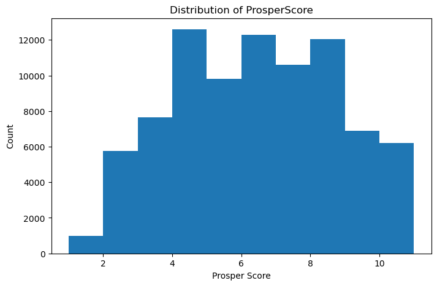

# Distribution of Occupation of Employment Status

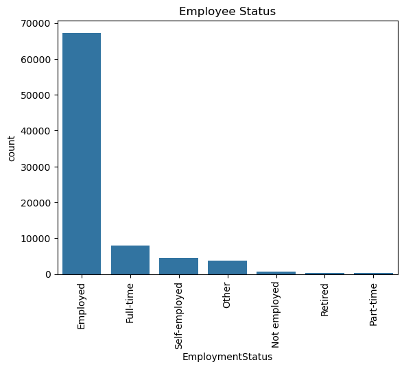

# Distribution of IncomeGroup, Employment status, Term over prosper score

As we can see bellow, High and middle income earners have a higher prosper score than lower class income earners. Full time workers, people who are employed, part time workers do have a higher score comapare to sel-employed and unemployed works. As expected, if your employed, you have a higher chance of paying your loan hence higher score. supriseingly, the prosper scores for short term, middle and long term loans are thesame. hence term of loan is not a determiant of the prosper score.

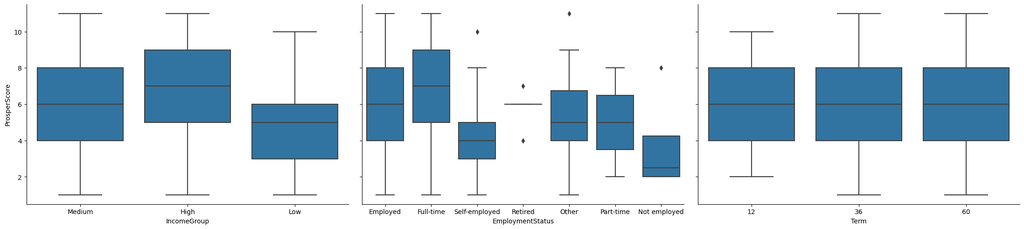

# Prosperscore vs Empoyment status and incomeverifiable

There is a strong variation of prosperscore for prople who are Employed and not employed with veriable source of income ahaist those who are employed and not employed without a veriable shource of income.

Hence, Employment status with verifiable income are huge determinants of prosperscore

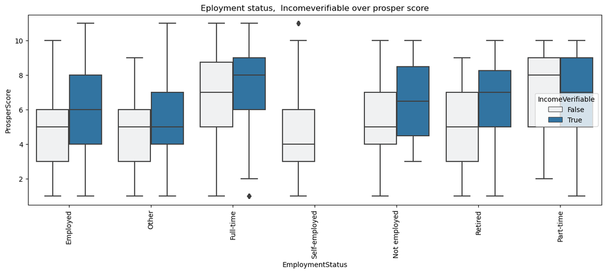

# Prosperscore, Loan category and Term

Household Expenses, Mdedical/Dental, Auto, Home improvement, large purchase with short term loans have a higher score comapred to those with middle and long term loans

Students have only Middle loans of 36 months available for their disposal

Hence, loan category and the Term of loan have a major role in determining the prosperscore

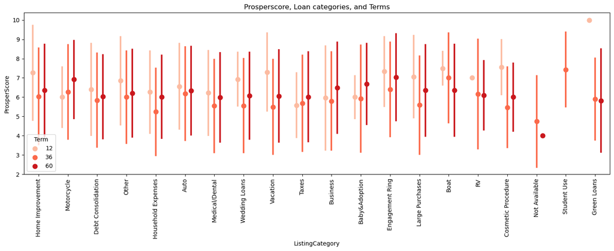

# Prosperscore, loan status and employment status

Hence strong determinants of the prosperscore.

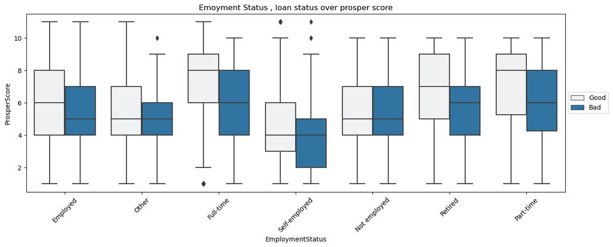

# Conclusion

The following variables are strong determinants of the Prosperscore:

Loan categories and Loan Term: Household Expenses, Mdedical/Dental, Auto, Home improvement, large purchase with short term loans have a higher score

Incomegroup: High income earners have a higher Prosperscore

Loan status and Employment Status: Employees with good loan status have higher prosper score

Incomeverifiable: Employees with verifiable sources of income have a higher prosperscore